# Regression Supplement

James Muguira

March 28, 2016

# Synopsis

The practice of fitting a line to a set of points has *many* uses. For the purposes of this class I’ll refer to this practice as regession or regression analysis. Regression is related to interpolation. Interpolation is the practice of fitting a line to a set of points. Regression takes interpolation up another level, you are not just fitting the data, you are using that fitted line to: predict, assess relationships or describe some data.

This class will consider linear relationships and analysis. These linear relationships may employ multiple variables but we will still just be fitting a straight line to the data. The linear regression has the general form:

### y = m*x + b + er

Where:

- y is the dependent variable
- x is the independent variable
- M is the fit coefficient for the independent variable
- b is the y-intercept
- er is some error (or residual) associated with the line fitting algorithm

The coefficients: m and b are computed by adjuting the slope of the line to minimize the total combined distance from the estimating equation to each individual raw point. Many text books cover this concept so we’ll not cover it here. It is important to note that the error term (er) is composed of two elements: a specification error and a measurement error. The specification error comes from the fact that the model is a simplification of reality. We, as modelers decide to leave off certain aspects of the problem and these omitted variables may have unforeseen impacts on our model. The measurement error comes in the form of rounding, recording and missing data.

# Discussion

Regression is a form of data reduction. By that, I mean that a complex relationship between data points can be reduced to a more simple and easier to work with relationship. Consider the following data points.

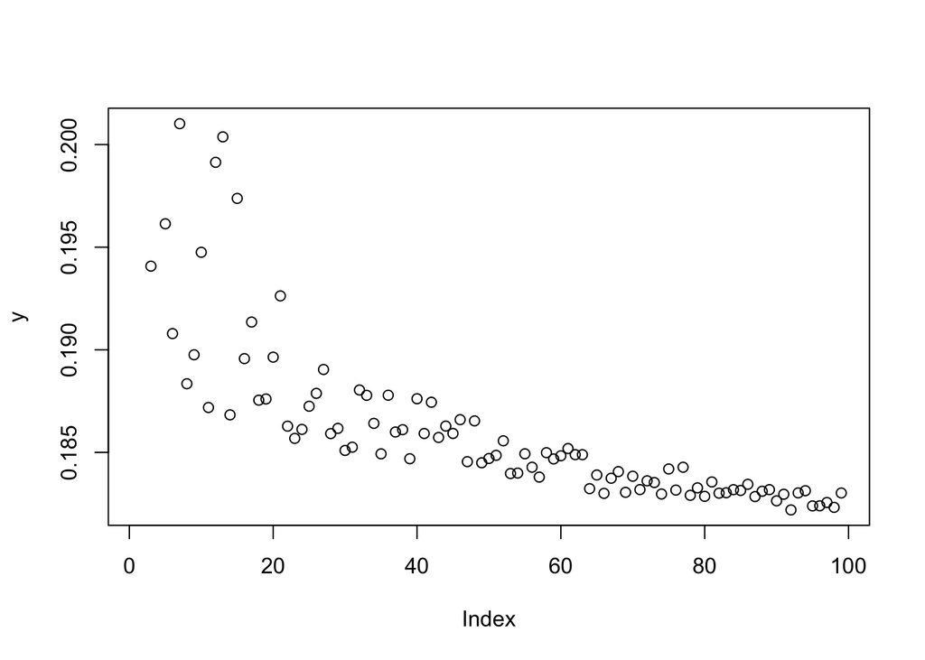

```r
tt = jitter(2:100, factor=90.3)
y = 0.2 * tt^(-0.02)
plot(y)
```

```r
l_fit = lm(y ~ tt)
summary(l_fit)
```

```
##
## Call:
## lm(formula = y ~ tt)
##
## Residuals:
##        Min         1Q     Median         3Q        Max
## -0.0017179 -0.0015335 -0.0006901  0.0008120  0.0090241
##
## Coefficients:
##               Estimate Std. Error t value Pr(>|t|)
## (Intercept)  1.921e-01  4.377e-04  438.81   <2e-16 ***
## tt          -1.175e-04  7.452e-06  -15.77   <2e-16 ***
## ---
## Signif. codes:  0 '***' 0.001 '**' 0.01 '*' 0.05 '.' 0.1 ' ' 1
##
## Residual standard error: 0.002086 on 94 degrees of freedom
##   (3 observations deleted due to missingness)
## Multiple R-squared:  0.7258, Adjusted R-squared:  0.7228
## F-statistic: 248.8 on 1 and 94 DF,  p-value: < 2.2e-16
```

This regression representation depends on the following conditions:

- The relatioship between the independent variable (x) and the dependent variable (y) is linear,
- The terms of the independent variable (the x sub i’s) are non random with fixed values,
- The error term has a constant variance,
- The dependent variables (each individual y sub i) are each independent.

Visually this relationship an be show with the following:

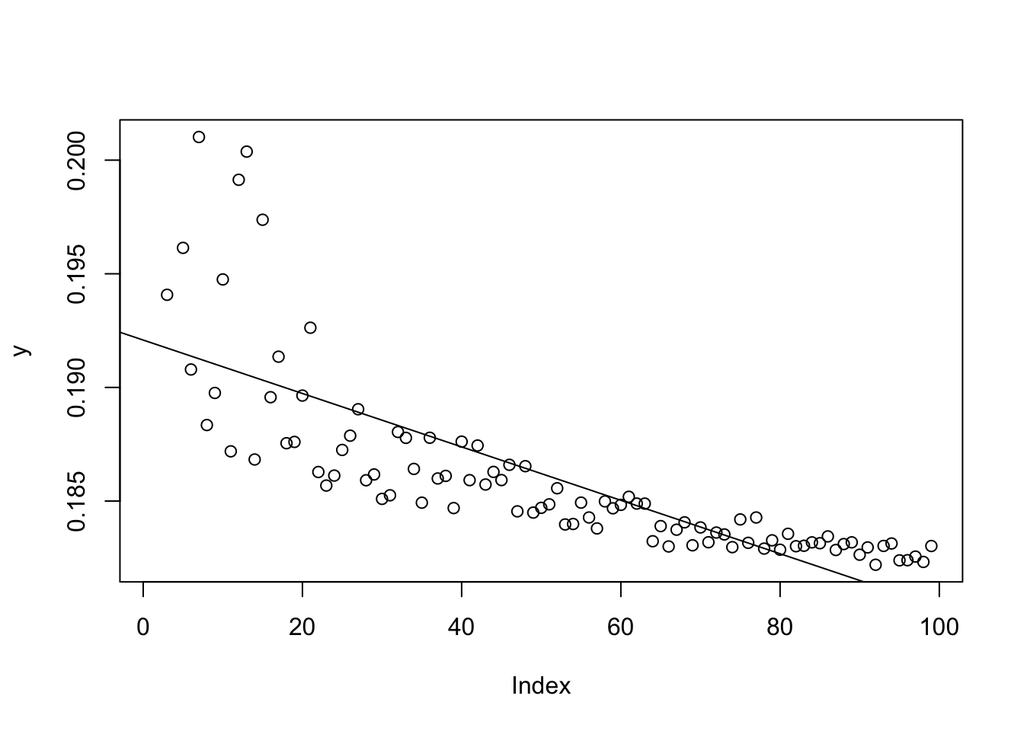

```r
plot(y)
abline(l_fit)
```

In text form the linear model is:

## Validation

We already have the tools to assess the validity of the regression equation: hypothesis testing. In this case we’ll employ our 5 step process.

- State a Null and Alternative Hypothesis. The Null hypothesis is established to test if the slope coefficient is zero (in most cases). This would imply that there is no rstatistical elationship between the independent and dependent variables.
- Select a level of significance or alpha.
- Compute a t-test to see if we accept of reject the Null hypothesis based on our choosen level of significance. For a two variable regression model evaluating the results of the t-test provide a straight forward validation of the model in terms of its predictive capability. Models invloving more variables utilize the additional aanalysis of variance statistics (the F-test and degrees of freedom) to assess validity.
- Compute a confidence interval around our t-value
- Compare our t-value to see if it lies inside the confidence interval.

As you can see, selection of the significance value (alpha) is subjective. The experience of the modeler and the dynamics of the problem provide some guidance but building models is as much an art as a science.

# Conclusion

Much more can be said about regression and validating the regression equation. This note has only touched the surface. One important take away from this discussion is the inter-relatedness of regression, analysis of variance and hypothesis testing. Another important take away is the concept of reduction of dimensions afforded by the regression analysis. This simplification of the problem space down to a few variables (or a forumla) is a powerful method to use to help understand complex situations.